# mlb.UBR

Quin Yuter

2023-07-28

```r
library(tidyverse)
```

```r
library(leaps)
library(ggplot2)
library(ggfortify)
library(caret)
library(car)
library(knitr)
```

data frame

```r
mlb.UBR <- read_csv("/Users/quinyuter/Desktop/Chicago Dogs/mlb.UBR.csv") %>%
  filter(!is.na(UBR))
## Because the American Association is only 64 games into the season, but the MLB was 100 games in at the time this information was taken, I need to do some simple proportions so that the stats line up. This only really matters for the stats that matter and that compound, aka stats that only increase that can only go up..
mlb.UBR <- mlb.UBR %>%
  mutate(across(c(b_rbi, b_total_bases, r_total_stolen_base, b_gnd_into_dp, r_run, ab, pa, single, hit, double, triple, home_run, strikeout, walk, ), function(x) x*(64/100)))
```

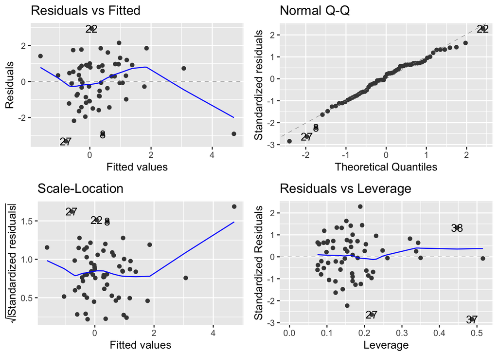

```r
UBR.full <- lm(UBR ~ pa + hit + single + double + triple + batting_avg + slg_percent + b_total_bases + r_total_stolen_base + b_gnd_into_dp + r_run, data = mlb.UBR)
autoplot(UBR.full)
```

The linearity assumption is broken, so we must transform the predictors

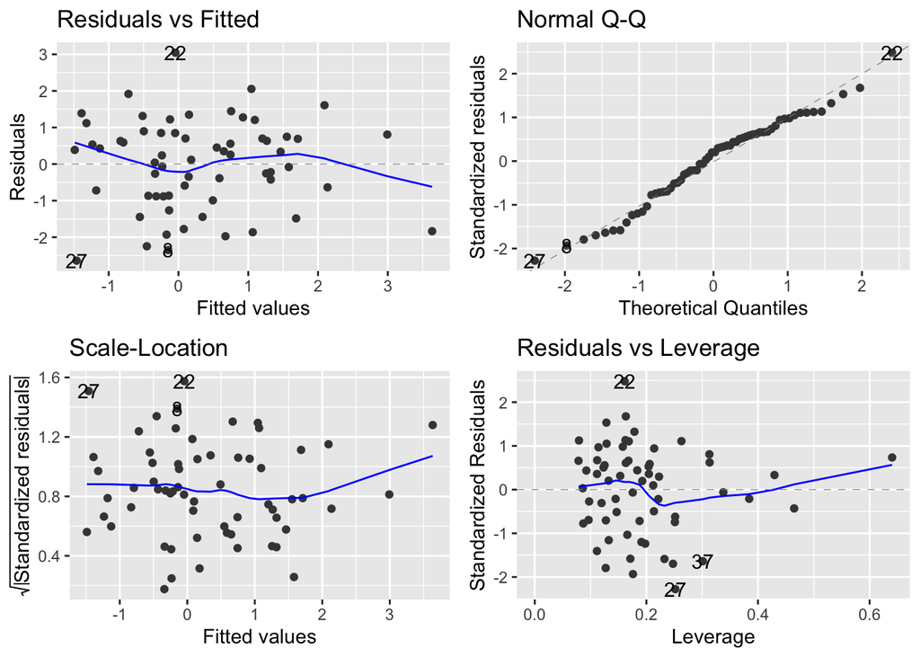

```r
UBR.full2 <- lm(UBR ~ sqrt(pa) + sqrt(hit) + sqrt(single) + sqrt(double) + sqrt(triple) + sqrt(batting_avg) + sqrt(slg_percent) + sqrt(b_total_bases) + sqrt(r_total_stolen_base) + sqrt(b_gnd_into_dp) + sqrt(r_run), data = mlb.UBR)
autoplot(UBR.full2)
```

The assumptions look much better satisfied, so lets move on.

## Model Selection

backwards

```r
UBR.back <- stats::step(UBR.full2, direction = "backward")
```

```
## Start:  AIC=46.96
## UBR ~ sqrt(pa) + sqrt(hit) + sqrt(single) + sqrt(double) + sqrt(triple) +
##     sqrt(batting_avg) + sqrt(slg_percent) + sqrt(b_total_bases) +
##     sqrt(r_total_stolen_base) + sqrt(b_gnd_into_dp) + sqrt(r_run)
##
##                             Df Sum of Sq     RSS    AIC
## - sqrt(slg_percent)          1     0.004  89.796 44.965
## - sqrt(batting_avg)          1     0.148  89.940 45.065
## - sqrt(b_total_bases)        1     0.967  90.759 45.626
## - sqrt(b_gnd_into_dp)        1     2.026  91.818 46.346
## - sqrt(pa)                   1     2.283  92.074 46.519
## - sqrt(hit)                  1     2.941  92.732 46.960
## <none>                                    89.792 46.962
## - sqrt(single)               1     3.287  93.079 47.191
## - sqrt(triple)               1     3.741  93.533 47.493
## - sqrt(double)               1     4.447  94.238 47.959
## - sqrt(r_run)                1     5.605  95.397 48.717
## - sqrt(r_total_stolen_base)  1    33.299 123.090 64.519
##
## Step:  AIC=44.96
## UBR ~ sqrt(pa) + sqrt(hit) + sqrt(single) + sqrt(double) + sqrt(triple) +
##     sqrt(batting_avg) + sqrt(b_total_bases) + sqrt(r_total_stolen_base) +
##     sqrt(b_gnd_into_dp) + sqrt(r_run)
##
##                             Df Sum of Sq     RSS    AIC
## - sqrt(b_gnd_into_dp)        1     2.026  91.822 44.349
## - sqrt(batting_avg)          1     2.358  92.154 44.572
## - sqrt(pa)                   1     2.363  92.159 44.575
## <none>                                    89.796 44.965
## - sqrt(b_total_bases)        1     3.273  93.069 45.185
## - sqrt(single)               1     3.320  93.115 45.216
## - sqrt(triple)               1     3.845  93.641 45.565
## - sqrt(hit)                  1     3.916  93.712 45.612
## - sqrt(double)               1     4.515  94.310 46.006
## - sqrt(r_run)                1     5.613  95.409 46.724
## - sqrt(r_total_stolen_base)  1    33.404 123.199 62.573
##
## Step:  AIC=44.35
## UBR ~ sqrt(pa) + sqrt(hit) + sqrt(single) + sqrt(double) + sqrt(triple) +
##     sqrt(batting_avg) + sqrt(b_total_bases) + sqrt(r_total_stolen_base) +
```

[output cut: 72 more lines]

```
##                             Df Sum of Sq     RSS    AIC
## - sqrt(single)               1     1.098  98.891 36.947
## - sqrt(double)               1     2.829 100.622 38.022
## <none>                                    97.793 38.255
## - sqrt(r_run)                1     5.665 103.458 39.746
## - sqrt(r_total_stolen_base)  1    41.227 139.020 58.064
##
## Step:  AIC=36.95
## UBR ~ sqrt(double) + sqrt(r_total_stolen_base) + sqrt(r_run)
##
##                             Df Sum of Sq     RSS    AIC
## <none>                                    98.891 36.947
## - sqrt(double)               1     4.662 103.553 37.803
## - sqrt(r_run)                1     5.477 104.368 38.289
## - sqrt(r_total_stolen_base)  1    40.215 139.105 56.102
```

```r
summary(UBR.back)
```

```
##
## Call:
## lm(formula = UBR ~ sqrt(double) + sqrt(r_total_stolen_base) +
##     sqrt(r_run), data = mlb.UBR)
##
## Residuals:
##     Min      1Q  Median      3Q     Max
## -2.8666 -0.8639  0.1361  1.0681  2.6787
##
## Coefficients:
##                           Estimate Std. Error t value Pr(>|t|)
## (Intercept)                -2.3084     1.6661  -1.385   0.1712
## sqrt(double)               -0.5819     0.3519  -1.654   0.1036
## sqrt(r_total_stolen_base)   0.8418     0.1733   4.857 9.42e-06 ***
## sqrt(r_run)                 0.5335     0.2977   1.792   0.0783 .
## ---
## Signif. codes:  0 '***' 0.001 '**' 0.01 '*' 0.05 '.' 0.1 ' ' 1
##
## Residual standard error: 1.306 on 58 degrees of freedom
## Multiple R-squared:  0.3816, Adjusted R-squared:  0.3496
## F-statistic: 11.93 on 3 and 58 DF,  p-value: 3.455e-06
```

forward

```r
UBR.null <- lm(UBR ~ 1, data = mlb.UBR)
UBR.forward <- step(UBR.null, scope = formula(UBR.full2), direction = "forward")
```

```
## Start:  AIC=60.74
## UBR ~ 1
##
##                             Df Sum of Sq    RSS    AIC
## + sqrt(r_total_stolen_base)  1    53.527 106.38 37.474
## + sqrt(r_run)                1    18.082 141.83 55.303
## + sqrt(b_gnd_into_dp)        1     8.614 151.29 59.310
## + sqrt(slg_percent)          1     7.545 152.36 59.746
## + sqrt(b_total_bases)        1     6.124 153.78 60.322
## <none>                                   159.91 60.743
## + sqrt(pa)                   1     2.539 157.37 61.751
## + sqrt(hit)                  1     1.519 158.39 62.151
## + sqrt(batting_avg)          1     0.390 159.52 62.592
## + sqrt(triple)               1     0.154 159.75 62.683
## + sqrt(double)               1     0.042 159.87 62.727
## + sqrt(single)               1     0.022 159.89 62.734
##
## Step:  AIC=37.47
## UBR ~ sqrt(r_total_stolen_base)
##
##                       Df Sum of Sq    RSS    AIC
## <none>                             106.38 37.474
## + sqrt(r_run)          1   2.82835 103.55 37.803
## + sqrt(b_gnd_into_dp)  1   2.52768 103.85 37.983
## + sqrt(batting_avg)    1   2.05561 104.33 38.264
## + sqrt(double)         1   2.01369 104.37 38.289
## + sqrt(single)         1   1.98709 104.39 38.304
## + sqrt(hit)            1   0.98147 105.40 38.899
## + sqrt(slg_percent)    1   0.82947 105.55 38.988
## + sqrt(triple)         1   0.50920 105.87 39.176
## + sqrt(b_total_bases)  1   0.09171 106.29 39.420
## + sqrt(pa)             1   0.03534 106.35 39.453
```

```r
summary(UBR.forward)
```

```
##
## Call:
## lm(formula = UBR ~ sqrt(r_total_stolen_base), data = mlb.UBR)
##
## Residuals:
##     Min      1Q  Median      3Q     Max
## -2.8379 -0.8686  0.1432  0.8835  3.2840
##
## Coefficients:
##                           Estimate Std. Error t value Pr(>|t|)
## (Intercept)                -1.3025     0.3379  -3.855 0.000285 ***
## sqrt(r_total_stolen_base)   0.9003     0.1638   5.495 8.42e-07 ***
## ---
## Signif. codes:  0 '***' 0.001 '**' 0.01 '*' 0.05 '.' 0.1 ' ' 1
##
## Residual standard error: 1.332 on 60 degrees of freedom
## Multiple R-squared:  0.3347, Adjusted R-squared:  0.3236
## F-statistic: 30.19 on 1 and 60 DF,  p-value: 8.424e-07
```

Best subsets regression

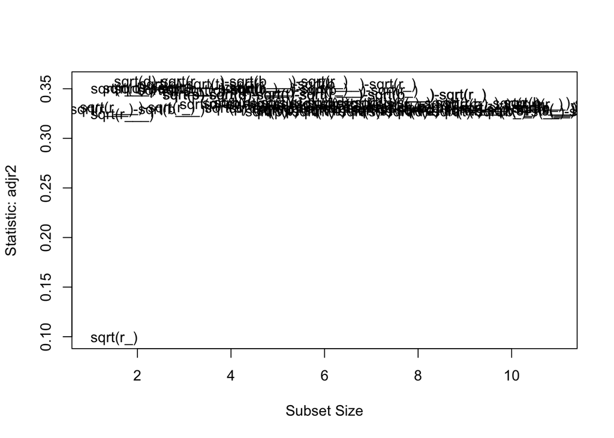

```
##                           Abbreviation
## sqrt(pa)                       sqrt(p)
## sqrt(hit)                      sqrt(h)
## sqrt(single)                   sqrt(s)
## sqrt(double)                   sqrt(d)
## sqrt(triple)                   sqrt(t)
## sqrt(batting_avg)             sqrt(b_)
## sqrt(slg_percent)             sqrt(s_)
## sqrt(b_total_bases)              s(__)
## sqrt(r_total_stolen_base)   sqrt(r___)
## sqrt(b_gnd_into_dp)         sqrt(b___)
## sqrt(r_run)                   sqrt(r_)
```

```r
library(leaps)
UBR.subs <- regsubsets(formula(UBR.full2), data = mlb.UBR, nbest = 2, nvmax = 10)

subsets(UBR.subs, statistic = "adjr2", legend = FALSE)
```

Although hard to see, it looks like subset size 3-4 has the highest Adjusted R-Squared value, so lets see the variables in those subset sizes

```r
summary(UBR.subs)
```

```
## Subset selection object
## Call: regsubsets.formula(formula(UBR.full2), data = mlb.UBR, nbest = 2,
##     nvmax = 10)
## 11 Variables  (and intercept)
##                           Forced in Forced out
## sqrt(pa)                      FALSE      FALSE
## sqrt(hit)                     FALSE      FALSE
## sqrt(single)                  FALSE      FALSE
## sqrt(double)                  FALSE      FALSE
## sqrt(triple)                  FALSE      FALSE
## sqrt(batting_avg)             FALSE      FALSE
## sqrt(slg_percent)             FALSE      FALSE
## sqrt(b_total_bases)           FALSE      FALSE
## sqrt(r_total_stolen_base)     FALSE      FALSE
## sqrt(b_gnd_into_dp)           FALSE      FALSE
```

[output cut: 66 more lines]

I am going to fit a model with 3 variables

```r
adjr3 <- lm(UBR ~ sqrt(r_total_stolen_base) + sqrt(b_gnd_into_dp) + sqrt(r_run), data = mlb.UBR)
```

bic

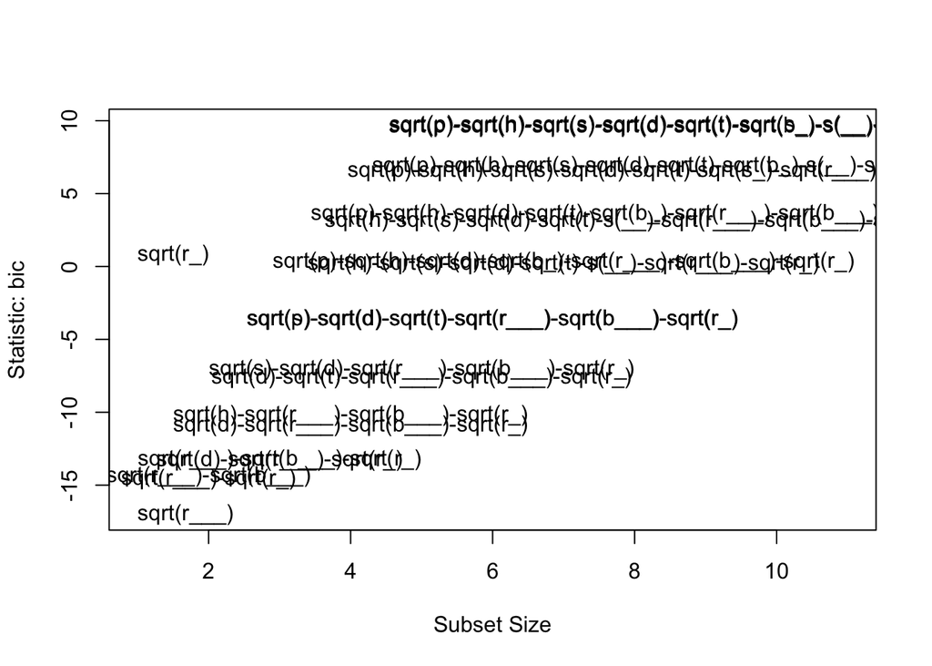

```
##                           Abbreviation
## sqrt(pa)                       sqrt(p)
## sqrt(hit)                      sqrt(h)
## sqrt(single)                   sqrt(s)
## sqrt(double)                   sqrt(d)
## sqrt(triple)                   sqrt(t)
## sqrt(batting_avg)             sqrt(b_)
## sqrt(slg_percent)             sqrt(s_)
## sqrt(b_total_bases)              s(__)
## sqrt(r_total_stolen_base)   sqrt(r___)
## sqrt(b_gnd_into_dp)         sqrt(b___)
## sqrt(r_run)                   sqrt(r_)
```

```r
subsets(UBR.subs, statistic = "bic", legend = FALSE)
```

The subset size with the lowest value bic looks to be just one variable (sqrt(r___)), but that isn’t a sufficient enough amount of variables, so I am going to use a 3 variable model. Looking at the summary from earlier, the other model with 3 variables uses the square root of total stolen bases, total runs, and total doubles

```r
bic3 <- lm(UBR ~ sqrt(r_total_stolen_base) + sqrt(double) + sqrt(r_run), data = mlb.UBR)
```

```r
library(broom)
bind_rows(
  glance(UBR.full2) %>% mutate(Model="Full Model"),
  glance(UBR.forward) %>% mutate(Model="Forward"),
  glance(UBR.back) %>% mutate(Model="Backward"),
  glance(adjr3) %>% mutate(Model="Best subsets: Adjusted R-squared"),
  glance(bic3) %>% mutate(Model="Best subsets: BIC")) %>%
  select(Model, `Adjusted R-Squared` = adj.r.squared,
         AIC, BIC) %>%
  kable()
```

| Model | Adjusted R-Squared | AIC | BIC |
| --- | --- | --- | --- |
| Full Model | 0.3149463 | 224.9106 | 252.5634 |
| Forward | 0.3236487 | 215.4219 | 221.8033 |
| Backward | 0.3495934 | 214.8949 | 225.5306 |
| Best subsets: Adjusted R-squared | 0.3490013 | 214.9513 | 225.5870 |
| Best subsets: BIC | 0.3495934 | 214.8949 | 225.5306 |

It looks like both the best subsets BIC model and the backward stepwise regression model are the same. I am choosing them because they have the highest adjusted R-squared value, the lowest AIC value, and the second lowest BIC value. Therefore, we are going to use total stolen bases, runs, and doubles to predict what the UBR would be for our players.

## Prediction

First, I am making a dataframe of the team, including their stolen bases, runs, and doubles, and eventually their predicted UBRs. I am also using the same column names as the other data frame for ease of transferring data.

```r
dogs.data <- data.frame(Player = c("Matt Bottcher", "Ryan Lidge", "Dylan Rosa", "David Maberry", "Josh Altmann", "Jesus Lujano", "Luke Mangieri", "Ben Livorsi", "Nick Heath", "Brennan Metzger", "Cody Bohanek", "Payton Eeles", "General McCarthur"), r_total_stolen_base = c(16, 1, 5, 0, 14, 9, 3, 0, 28, 4, 11, 1, 3), r_run = c(49, 41, 36, 12, 45, 28, 33, 14, 41, 27, 29, 5, 5), double = c(14, 11, 14, 7, 15, 10, 13, 4, 6, 7, 5, 1, 0), UBR = 0)
```

Now, using the data from before, and our players data, to predict their UBR values. I am going to round them to 1 decimal place, since that is how many decimal places are used in MLB’s stat

```r
## Matt botcher
dogs.data["1", "UBR"]<- round(predict(UBR.back, data.frame(r_total_stolen_base = 16, r_run = 49, double = 14)), 1)

## Ryan Lidge
dogs.data["2", "UBR"]<- round(predict(UBR.back, data.frame(r_total_stolen_base = 1, r_run = 41, double = 11)), 1)

## Dylan Rosa
dogs.data["3", "UBR"]<- round(predict(UBR.back, data.frame(r_total_stolen_base = 5, r_run = 36, double = 14)), 1)

## David Maberry
dogs.data["4", "UBR"]<- round(predict(UBR.back, data.frame(r_total_stolen_base = 0, r_run = 12, double = 7)), 1)

## Josh Altmann
dogs.data["5", "UBR"]<- round(predict(UBR.back, data.frame(r_total_stolen_base = 14, r_run = 45, double = 15)), 1)

## Jesus Lujano
dogs.data["6", "UBR"]<- round(predict(UBR.back, data.frame(r_total_stolen_base = 9, r_run = 28, double = 10)), 1)

## Luke Mangieri
dogs.data["7", "UBR"]<- round(predict(UBR.back, data.frame(r_total_stolen_base = 3, r_run = 33, double = 13)), 1)

## Ben Livorsi
dogs.data["8", "UBR"]<- round(predict(UBR.back, data.frame(r_total_stolen_base = 0, r_run = 14, double = 4)), 1)

## Nick Heath
dogs.data["9", "UBR"]<- round(predict(UBR.back, data.frame(r_total_stolen_base = 28, r_run = 41, double = 6)), 1)

## Payton Eeles
dogs.data["10", "UBR"]<- round(predict(UBR.back, data.frame(r_total_stolen_base = 1, r_run = 5, double = 1)), 1)

## Cody Bohanek
dogs.data["11", "UBR"]<- round(predict(UBR.back, data.frame(r_total_stolen_base = 11, r_run = 29, double = 5)), 1)
```